# Don’t Leave Us 2026

The games Phil is proposing to bring up north for the last shared cabin weekend as we try to cling to the good times and hold off the sadness while vaguely threatening each other

Author

Who do you think?

Published

July 30, 2026

# What is this?

This report contains the list of games Phil is proposing to bring to up north for our Definitely-Not-Dead-To-Us-After-This Cabin weekend. The current numbers:

15

In the Bag

11

Locks

13

Maybes

5

Sad People

The “locks” are the games that are **100% in the bag no question about it** I will fight any of you who try to argue with me.

The “maybes” are games I’m considering but would like someone else to weigh in on.

Games in the “other” category are games that technically fit my proposed criteria but I’m a bit wary of bringing because I’d have to brush up on rules.

**Criteria:**

- Support 5-6 players (some 4 player exceptions for if folks succeed in leaving us but that won’t happen haha)
- Light-hearted games preferred (to hold off the bad feelings)
- Cooperative games preferred (because it’s the last time we’ll cooperate haha)
- Small table footprint preferred (or else)
- One complex-ish game for the person we’re kidnapping

**Constraints:**

- Everything must fit into my [board game carrying bag](https://www.allplay.com/board-game-bags/premium)
- Except for Crokinole (because it’s the last chance to ever play it)

# What’s in the Box Bag

The games that are currently packed.

[figure not shown]

# The “Locks”

Games I am 100% bringing no arguments about it I will fight all of you at once.

[figure not shown]

Startups2017

Description from the publisher: There are six companies that will change the world as we know it! You can be part of their success and be an investor. Try to…

Players345ComplexityLightPlaytime20 min

[figure not shown]

The King's Dilemma2019

The King's Dilemma is an interactive narrative experience with legacy elements, featuring several branching storylines leading to many possible finales and an…

Players45ComplexityLight-MediumPlaytime45–60 min

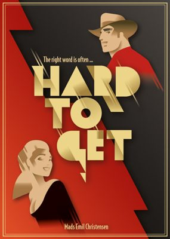

Hard to Get2023

The Witness knows the right word. The Detectives are on the case. In Hard to Get, players must work together to find the right word, which only the Witness kn…

Players34567ComplexityLightPlaytime15 min

[figure not shown]

Wine Cellar2025

Let's auction off some wine! You and your rival sommeliers have decided to face off to determine who is the best. Each person will take on a client, building a…

Players34567ComplexityLightPlaytime20 min

[figure not shown]

The Gang2024

Round up your gang and get ready to pull off a series of bank heists using the power of poker! In The Gang, a co-operative version of Texas Hold'em, players b…

Players456ComplexityLightPlaytime20 min

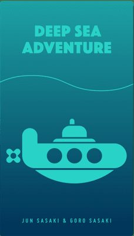

Deep Sea Adventure Boost2024

In Deep Sea Adventure, you and up to five other explorers are searching for riches under the sea, and while you're all rivals, you're also all poor, so you've…

Players23456ComplexityLightPlaytime30 min

[figure not shown]

The Lord of the Rings: The Fellowship of the Ring – Trick-Taking Game2024

The Fellowship of the Ring: Trick-Taking Game is a co-operative card game that plays out over eighteen chapters that lead players through the events of the nov…

Players34ComplexityLight-MediumPlaytime20 min

[figure not shown]

Ethnos: 2nd Edition2025

In the faraway land of Ethnos, a new Age is dawning. The ashes of the old Age have left the Six Regions empty, and the twelve Clans scattered to the winds. Now…

Players3456ComplexityLight-MediumPlaytime60 min

[figure not shown]

Hot Streak2025

Hot Streak is a game for hard luck gamblers who love to bet on and scream at the racers, who in this case happen to be mascots who may (or may not) keep runnin…

Players45678ComplexityLightPlaytime20 min

[figure not shown]

The Lord of the Rings: The Two Towers – Trick-Taking Game2026

The journey continues in the magical world of Middle-earth in The Two Towers: Trick-Taking Game, a narrative-driven co-operative card game that lets players ta…

Players34ComplexityLight-MediumPlaytime20 min

[figure not shown]

Magical Athlete2025

Magical Athlete is a racing game of pure chaos! Roll a die and move your racer that many spaces — but all the racers have wacky, game-breaking abilities. Race…

Players3456ComplexityLightPlaytime30 min

# The “Maybes”

Games under consideration but I’m tired.

[figure not shown]

El Grande1995

In this award-winning game, players take on the roles of Grandes in medieval Spain. The king's power is flagging, and these powerful lords are vying for contr…

Players45ComplexityMediumPlaytime60–120 min

[figure not shown]

Crokinole1876

Crokinole is a traditional two- or four-player dexterity game, played on a circular wooden board, with 3 rings and an inner recessed 'bullseye'. A ring of post…

Players24ComplexityLightPlaytime30 min

[figure not shown]

Cockroach Poker2004

Cockroach Poker is a reverse set collection game that has nothing to do with poker – except that the game is all about bluffing, with cards that show cockroach…

Players456ComplexityLightPlaytime20 min

[figure not shown]

Skull2011

Edited description from Bruno Faidutti's write-up of the game in his Ideal Game Library: Skull & Roses is the quintessence of bluffing, a game in which everyt…

Players456ComplexityLightPlaytime15–45 min

[figure not shown]

Concordia2013

Two thousand years ago, the Roman Empire ruled the lands around the Mediterranean Sea. With peace at the borders, harmony inside the provinces, uniform law, an…

Players2345ComplexityMediumPlaytime100 min

[figure not shown]

Coup2012

You are head of a family in an Italian city-state, a city run by a weak and corrupt court. You need to manipulate, bluff and bribe your way to power. Your obje…

Players456ComplexityLightPlaytime15 min

[figure not shown]

Crossing2013

In Crossing, you have to collect gemstones, but players make their choices simultaneously and not everybody will get what they want when desires clash — and ev…

Players456ComplexityLightPlaytime15 min

[figure not shown]

Century: Golem Edition2017

Century: Golem Edition is a re-themed version of Century: Spice Road set in the world of Caravania. In Century: Golem Edition, players are caravan leaders who…

Players2345ComplexityLightPlaytime30–45 min

[figure not shown]

Hansa Teutonica: Big Box2020

The multi-award-winning strategy game Hansa Teutonica is back in a Big Box edition including the base game and all expansions. In the game, players attempt to…

Players345ComplexityMediumPlaytime45–90 min

[figure not shown]

The Crew: Mission Deep Sea2021

The Crew: Mission Deep Sea plunges players into a cooperative card game unlike any other. As members of a deep-sea expedition, you and your fellow crew are on…

Players345ComplexityLight-MediumPlaytime20 min

[figure not shown]

Heat: Pedal to the Metal2022

Based on simple and intuitive hand management, Heat: Pedal to the Metal puts players in the driver's seat of intense car races, jockeying for position to cross…

Players23456ComplexityLight-MediumPlaytime30–60 min

[figure not shown]

Lords of Vegas2024

In Lords of Vegas you start out with empty lots, build small casinos, and expand them as your bankroll grows. Your rivals can build next door, and they just mi…

Players3456ComplexityMediumPlaytime60–90 min

[figure not shown]

The Lord of the Rings: Fate of the Fellowship2025

As members of The Fellowship and the allies who rise to aid them, you must embark on a journey that may either save or doom Middle-earth. Navigate a world bese…

Players1234ComplexityMedium-HeavyPlaytime60–150 min

# The “Others”

Other games that fit the criteria but someone argue with me.

[figure not shown]

Watson & Holmes2015

Watson & Holmes is a game of deduction set within the magnificent works of Arthur Conan Doyle. Two to seven aspiring detectives step into the shoes of Doctor W…

Players3456ComplexityLight-MediumPlaytime45–75 min

[figure not shown]

Junk Art2016

In Junk Art, players are presented with junk from which they must create art. Thus the name. Junk Art contains more than ten game modes, along with more than…

Players23456ComplexityLightPlaytime30 min

[figure not shown]

DOOM: The Board Game2016

Description from the publisher: DOOM: The Board Game is strategy board game of tactical combat for 2-5 players based on Bethesda and id Software's video game…

Players345ComplexityMediumPlaytime120–180 min

[figure not shown]

Tiny Towns2019

You are the mayor of a tiny town in the forest in which the smaller creatures of the woods have created a civilization hidden away from predators. This new lan…

Players234ComplexityLight-MediumPlaytime45–60 min

[figure not shown]

Unfathomable2021

The year is 1913. The steamship SS Atlantica is two days out from port on its voyage across the Atlantic Ocean. Its unsuspecting passengers fully anticipated a…

Players456ComplexityMedium-HeavyPlaytime120–240 min

[figure not shown]

Twilight Inscription2022

The Lazax Empire has burned to ash, rejected by its subjects. The aftermath was tragedy and petty conflict in equal measure, a time of loss and exhaustion. In…

Players12345ComplexityMedium-HeavyPlaytime90–120 min

[figure not shown]

Wilmot's Warehouse2024

In Wilmot's Warehouse, your team will work co-operatively to organize the warehouse, using memory, imagination, and silly stories you make up. Draw product ti…

Players23456ComplexityLightPlaytime30 min